# Python 数据分析大作业-2班-1925101034-许思娜

# 1.导入所有模块

```python
import pandas as pd
import sklearn
from dateutil.parser import parse
import re
from textblob import TextBlob
import matplotlib.pyplot as plt
import seaborn as sns
from statsmodels.tsa.statespace.varmax import VARMAX
from datetime import datetime
import os
from matplotlib.ticker import FuncFormatter
from sklearn.preprocessing import StandardScaler
```

# 2.处理所有数据

## 2.1处理全标题数据

```python
judge_TIME=re.compile(r'((.*AM )|(.*PM ))$',re.DOTALL)#正则表达式，判断是否符合日期格式
dfa = pd.read_excel('全标题.xlsx', sheet_name='Sheet1')
for i in range(len(dfa)):
    if(dfa['ABOUT'][i]=="Editors' Pick "):
        dfa['ABOUT'][i]="Editors' Pick "+dfa['TIME'][i]
        dfa['TIME'][i]=dfa['AUTHOR'][i]
        dfa['AUTHOR'][i]=dfa['COMMENTS'][i]
        dfa['COMMENTS'][i]=dfa['Unnamed: 6'][i]#评论数归位
    if(len(re.findall(judge_TIME,dfa['TIME'][i]))==0):
        dfa['TIME'][i]=dfa['ABOUT'][i]
        dfa['COMMENTS'][i]=dfa['AUTHOR'][i]#评论数归位
    dfa['TIME'][i]=parse(dfa['TIME'][i])
dfa=dfa.dropna(subset=['COMMENTS'])
dfa.head()#dfa=>全标题数据读取的dataframe
```

|  | 标题 | 字段1_链接_链接 | ABOUT | TIME | AUTHOR | COMMENTS | Unnamed: 6 |
| --- | --- | --- | --- | --- | --- | --- | --- |
| 0 | Micron Technology: Insanely Cheap Stock Given ... | https://seekingalpha.com/article/4230920-micro... | MU | 2018-12-31 19:57:00 | Ruerd Heeg | 75 Comments | NaN |
| 1 | Molson Coors Seems Attractive At These Valuations | https://seekingalpha.com/article/4230922-molso... | TAP | 2018-12-31 19:44:00 | Sanjit Deepalam | 16 Comments | NaN |
| 2 | Gerdau: The Brazilian Play On U.S. Steel | https://seekingalpha.com/article/4230917-gerda... | GGB | 2018-12-31 19:10:00 | Shannon Bruce | 1 Comment | NaN |
| 3 | Will Apple Get Its Mojo Back? | https://seekingalpha.com/article/4230908-will-... | AAPL | 2018-12-31 17:36:00 | TipRanks | 68 Comments | NaN |
| 4 | Lululemon Stock Looks Compelling On This Dip | https://seekingalpha.com/article/4230907-lulul... | LULU | 2018-12-31 17:26:00 | L&F Capital Management | 4 Comments | NaN |

## 2.2处理摘要数据

```python
df_abs=pd.read_excel('摘要.xlsx',sheet_name='SA1-10_15')
#将字段1替换成情感系数，字段2替换成datetime
for i in range(len(df_abs)):
    blob = TextBlob(df_abs['字段1'].iloc[i])
    df_abs['字段1'].iloc[i] = str(blob.sentiment.polarity)
    tempa=parse(df_abs['字段2'].iloc[i])
    df_abs['字段2'].iloc[i] =datetime(tempa.year,tempa.month,tempa.day)
df_abs.head()
```

|  | 标题 | 字段2 | 字段5 | 字段1 |
| --- | --- | --- | --- | --- |
| 0 | HealthEquity: Strong Growth May Be Slowing Hea... | 2019-04-01 00:00:00 | \| About: HealthEquity, Inc. (HQY) | -0.048571428571428564 |
| 1 | Valero May Rally Up To 40% Within The Next 12 ... | 2019-04-01 00:00:00 | \| About: Valero Energy Corporation (VLO) | 0.15662337662337664 |
| 2 | Apple Makes A China Move | 2019-04-01 00:00:00 | \| About: Apple Inc. (AAPL) | 0.25 |
| 3 | Polaris Industries: Ready To Rally | 2019-04-01 00:00:00 | \| About: Polaris Industries Inc. (PII) | 0.11000000000000001 |
| 4 | How Apple Will Return A Minimum Of 8% By The E... | 2019-04-01 00:00:00 | \| About: Apple Inc. (AAPL) | 0.14537037037037037 |

## 2.3处理股票价格数据

```python
df_stock=pd.read_csv('股票价格.csv')
df_stock.head()
```

|  | PERMNO | date | TICKER | COMNAM | BIDLO | ASKHI | PRC | VOL | OPENPRC |
| --- | --- | --- | --- | --- | --- | --- | --- | --- | --- |
| 0 | 10026 | 20180702 | JJSF | J & J SNACK FOODS CORP | 150.70000 | 153.27499 | 152.92000 | 100388.0 | 152.17999 |
| 1 | 10026 | 20180703 | JJSF | J & J SNACK FOODS CORP | 151.35001 | 153.73000 | 153.32001 | 55547.0 | 153.67000 |
| 2 | 10026 | 20180705 | JJSF | J & J SNACK FOODS CORP | 152.46001 | 156.00000 | 155.81000 | 199370.0 | 153.95000 |
| 3 | 10026 | 20180706 | JJSF | J & J SNACK FOODS CORP | 154.80000 | 158.44000 | 158.42999 | 127431.0 | 156.00000 |
| 4 | 10026 | 20180709 | JJSF | J & J SNACK FOODS CORP | 154.44000 | 159.05000 | 154.53000 | 97661.0 | 158.60001 |

## 2.4处理论坛数据

```python
df_forum=pd.read_csv('论坛.csv')
df_forum=df_forum.dropna(subset=["字段3"])#处理字段3缺失值
df_forum.head()
```

|  | 字段1 | 字段2 | 字段3 | 字段4_链接 |
| --- | --- | --- | --- | --- |
| 0 | ComputerBlue | 31-Dec-18 | Let's create a small spec POS portfolio $COTY ... | https://seekingalpha.com/symbol/COTY |
| 1 | Darren McCammon | 31-Dec-18 | $RICK "Now that we've reported results, we'll ... | https://seekingalpha.com/symbol/RICK |
| 2 | Jonathan Cooper | 31-Dec-18 | Do any $APHA shareholders support the $GGB tak... | https://seekingalpha.com/symbol/APHA |
| 3 | lstasel | 31-Dec-18 | Long on $T . Even if it means smaller dividend... | https://seekingalpha.com/symbol/T |
| 4 | Nicholas Ward | 31-Dec-18 | 2018 was a down year for me, but I'm happy to ... | https://seekingalpha.com/symbol/SPY |

### 2.4.1根据链接提取对应公司简写

```python
df_url=df_forum.copy()
#print(len(df_url))
df_url = df_url.dropna(subset=["字段4_链接"])
df_url=df_url.reset_index(drop=True)
# df_url.iloc[:50,:]
df_url['字段5_简写']=''
for idx in df_url.index:
    df_url['字段5_简写'][idx]=df_url['字段4_链接'][idx].split("/")[-1]
df_url.head()
```

|  | 字段1 | 字段2 | 字段3 | 字段4_链接 | 字段5_简写 |
| --- | --- | --- | --- | --- | --- |
| 0 | ComputerBlue | 31-Dec-18 | Let's create a small spec POS portfolio $COTY ... | https://seekingalpha.com/symbol/COTY | COTY |
| 1 | Darren McCammon | 31-Dec-18 | $RICK "Now that we've reported results, we'll ... | https://seekingalpha.com/symbol/RICK | RICK |
| 2 | Jonathan Cooper | 31-Dec-18 | Do any $APHA shareholders support the $GGB tak... | https://seekingalpha.com/symbol/APHA | APHA |
| 3 | lstasel | 31-Dec-18 | Long on $T . Even if it means smaller dividend... | https://seekingalpha.com/symbol/T | T |
| 4 | Nicholas Ward | 31-Dec-18 | 2018 was a down year for me, but I'm happy to ... | https://seekingalpha.com/symbol/SPY | SPY |

## 2.5处理回帖数据

```python
%%time
all_data_frame=pd.DataFrame()
file_dir="回帖"
all_file_list=os.listdir(file_dir)
for single_file in all_file_list:
    # 逐个读取
    if(single_file.endswith(".csv")):
        single_data_frame=pd.read_csv(file_dir+'\\'+single_file)
    elif(single_file.endswith(".xlsx")):
        single_data_frame=pd.read_excel(file_dir+'\\'+single_file,sheet_name="Sheet1")
        single_data_frame.rename(columns={'字段':'字段1','标题1':'标题'},inplace=True)
    if single_file ==all_file_list[0]:
        all_data_frame=single_data_frame
    else:  #进行concat操作
         all_data_frame=pd.concat([all_data_frame,
                    single_data_frame],ignore_index=True)

all_data_frame.head()
```

```
Wall time: 6.19 s
```

|  | 字段1 | 标题 |
| --- | --- | --- |
| 0 | Does anyone know if Corning is going to be inv... | NaN |
| 1 | I’m a communications engineer. All my clients ... | NaN |
| 2 | @Prasanna Rajagopal Thanks for the excellent o... | NaN |
| 3 | Flip phones?? | NaN |
| 4 | Author’s reply » | NaN |

### 2.5.1向上填充缺失标题（bfill)

```python
all_data_frame = all_data_frame.fillna(method='bfill')#向上填充数据
all_data_frame.head()
```

|  | 字段1 | 标题 |
| --- | --- | --- |
| 0 | Does anyone know if Corning is going to be inv... | Corning: A Unique Company Playing In Multiple ... |
| 1 | I’m a communications engineer. All my clients ... | Corning: A Unique Company Playing In Multiple ... |
| 2 | @Prasanna Rajagopal Thanks for the excellent o... | Corning: A Unique Company Playing In Multiple ... |
| 3 | Flip phones?? | Corning: A Unique Company Playing In Multiple ... |
| 4 | Author’s reply » | Corning: A Unique Company Playing In Multiple ... |

# 以上完成了对所有数据进行完读取，与粗略清洗

# 3.对特定的公司，进行数据提取，对该公司的所有有效数据进行数据合并

## 3.1输入选定公司的简写

```python
print("请输入公司简写：")
>>> selected_company = input("input:")
selected_company
```

```
请输入公司简写：
input:TSLA
```

```
'TSLA'
```

## 3.2提取选定公司对应的全标题、摘要、论坛、回帖数据

### selected_company对应的股票价格数据

```python
df_stk_selected_company=df_stock.copy()
df_stk_selected_company=df_stk_selected_company[df_stk_selected_company['TICKER']==selected_company]
for i in range(len(df_stk_selected_company)):
    tempa=parse(str(df_stk_selected_company['date'].iloc[i]))
    df_stk_selected_company['date'].iloc[i]=datetime(tempa.year,tempa.month,tempa.day)
df_stk_selected_company.head()
```

|  | PERMNO | date | TICKER | COMNAM | BIDLO | ASKHI | PRC | VOL | OPENPRC |
| --- | --- | --- | --- | --- | --- | --- | --- | --- | --- |
| 941392 | 93436 | 2018-07-02 00:00:00 | TSLA | TESLA INC | 329.85001 | 364.78000 | 335.07001 | 18758595.0 | 360.07001 |
| 941393 | 93436 | 2018-07-03 00:00:00 | TSLA | TESLA INC | 309.69000 | 332.48999 | 310.85999 | 12282438.0 | 331.75000 |
| 941394 | 93436 | 2018-07-05 00:00:00 | TSLA | TESLA INC | 296.22000 | 314.39001 | 309.16000 | 17472474.0 | 313.76001 |
| 941395 | 93436 | 2018-07-06 00:00:00 | TSLA | TESLA INC | 302.00000 | 312.07001 | 308.89999 | 8861551.0 | 304.95499 |
| 941396 | 93436 | 2018-07-09 00:00:00 | TSLA | TESLA INC | 308.00000 | 318.51999 | 318.51001 | 7594053.0 | 311.98999 |

### selected_company对应的摘要数据

```python
#自定义正则表达式提取
lockallinfoabout=re.compile(r'\((.*?)\)',re.DOTALL)
df_abs_selected_company=df_abs.copy()#副本
for i in range(len(df_abs_selected_company)):
    if(len(re.findall(lockallinfoabout,df_abs_selected_company['字段5'][i]))==0):
        df_abs_selected_company.drop(i,inplace=True)
    else:
        if(re.findall(lockallinfoabout,df_abs_selected_company['字段5'][i])[0]!=selected_company):
            df_abs_selected_company.drop(i,inplace=True)
df_abs_selected_company.head()
```

|  | 标题 | 字段2 | 字段5 | 字段1 |
| --- | --- | --- | --- | --- |
| 13 | Tesla: Q1 Headwinds Could Create A Buying Oppo... | 2019-04-01 00:00:00 | \| About: Tesla, Inc. (TSLA) | -0.08773148148148148 |
| 93 | Tesla Sales Staff Fight For Survival Amid Quar... | 2019-03-28 00:00:00 | \| About: Tesla, Inc. (TSLA) | 0.06785714285714287 |
| 100 | Tesla's Growing GHG Credit Treasure Chest | 2019-03-28 00:00:00 | \| About: Tesla, Inc. (TSLA), Includes: FCAU | 0.24666666666666667 |
| 175 | My Q1 2019 Unit Sales Estimate For Tesla: 60,8... | 2019-03-26 00:00:00 | \| About: Tesla, Inc. (TSLA) | 0.03995726495726496 |
| 362 | Tesla: 2019 Production Guidance Mayhem | 2019-03-21 00:00:00 | \| About: Tesla, Inc. (TSLA) | 0.27714285714285714 |

### selected_company对应的论坛数据

```python
df_forum_selected_company=df_url[df_url['字段5_简写']==selected_company].copy()
for i in range(len(df_forum_selected_company)):
    blob = TextBlob(df_forum_selected_company['字段3'].iloc[i])
    df_forum_selected_company['字段3'].iloc[i] = blob.sentiment.polarity
    df_forum_selected_company['字段2'].iloc[i]= parse(df_forum_selected_company['字段2'].iloc[i])  #论坛数据本身就只到日
df_forum_selected_company.head()
```

|  | 字段1 | 字段2 | 字段3 | 字段4_链接 | 字段5_简写 |
| --- | --- | --- | --- | --- | --- |
| 13 | Calculus | 2018-12-31 00:00:00 | 0.0171 | https://seekingalpha.com/symbol/TSLA | TSLA |
| 18 | Bill Maurer | 2018-12-31 00:00:00 | 0.0 | https://seekingalpha.com/symbol/TSLA | TSLA |
| 37 | Sunil Shah | 2018-12-31 00:00:00 | 0.0 | https://seekingalpha.com/symbol/TSLA | TSLA |
| 78 | DontFollowMyAdviceImaDummy | 2018-12-28 00:00:00 | 1.0 | https://seekingalpha.com/symbol/TSLA | TSLA |
| 79 | Idaho Stoic | 2018-12-28 00:00:00 | 0.027381 | https://seekingalpha.com/symbol/TSLA | TSLA |

### selected_company对应的全部标题（ABOUT)

```python
df_atitle=dfa.copy()#已经处理过错位了（评论数和日期）
df_atitle_selected_company=df_atitle[df_atitle['ABOUT']==selected_company]
df_atitle_selected_company=df_atitle_selected_company.dropna(subset=['COMMENTS'])#去掉空
df_atitle_selected_company.head()
```

|  | 标题 | 字段1_链接_链接 | ABOUT | TIME | AUTHOR | COMMENTS | Unnamed: 6 |
| --- | --- | --- | --- | --- | --- | --- | --- |
| 27 | Tesla Offers To Forgive Your Lease Payments If... | https://seekingalpha.com/article/4230838-tesla... | TSLA | 2018-12-31 11:22:00 | Anton Wahlman | 131 Comments | NaN |
| 97 | Tesla Stock: Irrational Exuberance With Stayin... | https://seekingalpha.com/article/4230539-tesla... | TSLA | 2018-12-28 12:14:00 | D. H. Taylor | 239 Comments | NaN |
| 119 | Tesla Down 40% In Norway's Q4, 63% Of Which Ex... | https://seekingalpha.com/article/4230459-tesla... | TSLA | 2018-12-27 18:27:00 | Anton Wahlman | 543 Comments | NaN |
| 167 | Tesla Hits A Wall In China | https://seekingalpha.com/article/4230283-tesla... | TSLA | 2018-12-26 17:59:00 | John Engle | 245 Comments | NaN |
| 289 | Bill Fleckenstein: Now Is The Time To Short Te... | https://seekingalpha.com/article/4229853-bill-... | TSLA | 2018-12-23 13:35:00 | Quoth the Raven | 228 Comments | NaN |

## 3.3对全标题的标题根据评论数进行加权处理

```python
# (int(df_atitle_TSLA['COMMENTS'].values[0].split()[0]))
for idx in df_atitle_selected_company.index:
    df_atitle_selected_company['COMMENTS'][idx]=df_atitle_selected_company['COMMENTS'][idx].split()[0]
df_atitle_selected_company['COMMENTS']=df_atitle_selected_company['COMMENTS'].astype('int32')
df_atitle_selected_company['weight']=0.0
total_comments=df_atitle_selected_company['COMMENTS'].sum()#评论总数
for idx in df_atitle_selected_company.index:
    df_atitle_selected_company['weight'][idx]=df_atitle_selected_company['COMMENTS'][idx]/total_comments
df_atitle_selected_company.head()
```

|  | 标题 | 字段1_链接_链接 | ABOUT | TIME | AUTHOR | COMMENTS | Unnamed: 6 | weight |
| --- | --- | --- | --- | --- | --- | --- | --- | --- |
| 27 | Tesla Offers To Forgive Your Lease Payments If... | https://seekingalpha.com/article/4230838-tesla... | TSLA | 2018-12-31 11:22:00 | Anton Wahlman | 131 | NaN | 0.001044 |
| 97 | Tesla Stock: Irrational Exuberance With Stayin... | https://seekingalpha.com/article/4230539-tesla... | TSLA | 2018-12-28 12:14:00 | D. H. Taylor | 239 | NaN | 0.001905 |
| 119 | Tesla Down 40% In Norway's Q4, 63% Of Which Ex... | https://seekingalpha.com/article/4230459-tesla... | TSLA | 2018-12-27 18:27:00 | Anton Wahlman | 543 | NaN | 0.004329 |
| 167 | Tesla Hits A Wall In China | https://seekingalpha.com/article/4230283-tesla... | TSLA | 2018-12-26 17:59:00 | John Engle | 245 | NaN | 0.001953 |
| 289 | Bill Fleckenstein: Now Is The Time To Short Te... | https://seekingalpha.com/article/4229853-bill-... | TSLA | 2018-12-23 13:35:00 | Quoth the Raven | 228 | NaN | 0.001818 |

## 3.4找到selected_company对应所有文章标题的回帖，计算该标题的所有回帖情感系数均值

```python
# df_atitle_TSLA.values[1][0]
df_atitle_selected_company['回帖情感系数']='0'

for j in df_atitle_selected_company.index:
    Emotion_v_selected_company=0
    df_one_article = all_data_frame[all_data_frame['标题'] == df_atitle_selected_company['标题'][j]]
    if len(df_one_article) != 0:
        for article in df_one_article['字段1']:
            blob = TextBlob(article)
            Emotion_v_selected_company+=blob.sentiment.polarity
    if(len(df_one_article) != 0):
        df_atitle_selected_company['回帖情感系数'][j]=str((Emotion_v_selected_company/len(df_one_article)*df_atitle_selected_company.weight[j]*1000))
df_atitle_selected_company.head()
```

|  | 标题 | 字段1_链接_链接 | ABOUT | TIME | AUTHOR | COMMENTS | Unnamed: 6 | weight | 回帖情感系数 |
| --- | --- | --- | --- | --- | --- | --- | --- | --- | --- |
| 27 | Tesla Offers To Forgive Your Lease Payments If... | https://seekingalpha.com/article/4230838-tesla... | TSLA | 2018-12-31 11:22:00 | Anton Wahlman | 131 | NaN | 0.001044 | 0.07120714950685127 |
| 97 | Tesla Stock: Irrational Exuberance With Stayin... | https://seekingalpha.com/article/4230539-tesla... | TSLA | 2018-12-28 12:14:00 | D. H. Taylor | 239 | NaN | 0.001905 | 0.4128036903879318 |
| 119 | Tesla Down 40% In Norway's Q4, 63% Of Which Ex... | https://seekingalpha.com/article/4230459-tesla... | TSLA | 2018-12-27 18:27:00 | Anton Wahlman | 543 | NaN | 0.004329 | 0.35489168659021936 |
| 167 | Tesla Hits A Wall In China | https://seekingalpha.com/article/4230283-tesla... | TSLA | 2018-12-26 17:59:00 | John Engle | 245 | NaN | 0.001953 | 0 |
| 289 | Bill Fleckenstein: Now Is The Time To Short Te... | https://seekingalpha.com/article/4229853-bill-... | TSLA | 2018-12-23 13:35:00 | Quoth the Raven | 228 | NaN | 0.001818 | 0 |

## 3.5时间处理——时间只要年月日（具体到某天）

```python
for i in range(len(df_atitle_selected_company)):
    tempa=parse(str(df_atitle_selected_company['TIME'].iloc[i]))
    df_atitle_selected_company['TIME'].iloc[i]=datetime(tempa.year,tempa.month,tempa.day)
df_atitle_selected_company.head()
```

|  | 标题 | 字段1_链接_链接 | ABOUT | TIME | AUTHOR | COMMENTS | Unnamed: 6 | weight | 回帖情感系数 |
| --- | --- | --- | --- | --- | --- | --- | --- | --- | --- |
| 27 | Tesla Offers To Forgive Your Lease Payments If... | https://seekingalpha.com/article/4230838-tesla... | TSLA | 2018-12-31 00:00:00 | Anton Wahlman | 131 | NaN | 0.001044 | 0.07120714950685127 |
| 97 | Tesla Stock: Irrational Exuberance With Stayin... | https://seekingalpha.com/article/4230539-tesla... | TSLA | 2018-12-28 00:00:00 | D. H. Taylor | 239 | NaN | 0.001905 | 0.4128036903879318 |
| 119 | Tesla Down 40% In Norway's Q4, 63% Of Which Ex... | https://seekingalpha.com/article/4230459-tesla... | TSLA | 2018-12-27 00:00:00 | Anton Wahlman | 543 | NaN | 0.004329 | 0.35489168659021936 |
| 167 | Tesla Hits A Wall In China | https://seekingalpha.com/article/4230283-tesla... | TSLA | 2018-12-26 00:00:00 | John Engle | 245 | NaN | 0.001953 | 0 |
| 289 | Bill Fleckenstein: Now Is The Time To Short Te... | https://seekingalpha.com/article/4229853-bill-... | TSLA | 2018-12-23 00:00:00 | Quoth the Raven | 228 | NaN | 0.001818 | 0 |

## 全标题+回帖情感系数加权计算完毕

## 3.6股票价格与全标题+回帖情感系数合并link1

```python
df_link1=pd.merge(df_stk_selected_company,df_atitle_selected_company,left_on='date',right_on='TIME')
df_link1['回帖情感系数']=df_link1['回帖情感系数'].astype('float32')
df_link1.head()
```

|  | PERMNO | date | TICKER | COMNAM | BIDLO | ASKHI | PRC | VOL | OPENPRC | 标题 | 字段1_链接_链接 | ABOUT | TIME | AUTHOR | COMMENTS | Unnamed: 6 | weight | 回帖情感系数 |
| --- | --- | --- | --- | --- | --- | --- | --- | --- | --- | --- | --- | --- | --- | --- | --- | --- | --- | --- |
| 0 | 93436 | 2018-07-02 00:00:00 | TSLA | TESLA INC | 329.85001 | 364.78000 | 335.07001 | 18758595.0 | 360.07001 | Tesla Model 3 Sales Missed Consensus By 34% In Q2 | https://seekingalpha.com/article/4185089-tesla... | TSLA | 2018-07-02 00:00:00 | Anton Wahlman | 284 | NaN | 0.002264 | 0.276038 |
| 1 | 93436 | 2018-07-03 00:00:00 | TSLA | TESLA INC | 309.69000 | 332.48999 | 310.85999 | 12282438.0 | 331.75000 | Has Tesla Hit The 200K Vehicle Delivery Thresh... | https://seekingalpha.com/article/4185248-tesla... | TSLA | 2018-07-03 00:00:00 | John Engle | 345 | NaN | 0.002750 | 0.220539 |
| 2 | 93436 | 2018-07-05 00:00:00 | TSLA | TESLA INC | 296.22000 | 314.39001 | 309.16000 | 17472474.0 | 313.76001 | Questions For Tesla's Q2 Financial Results Call | https://seekingalpha.com/article/4185561-quest... | TSLA | 2018-07-05 00:00:00 | Anton Wahlman | 252 | NaN | 0.002009 | 0.153255 |
| 3 | 93436 | 2018-07-06 00:00:00 | TSLA | TESLA INC | 302.00000 | 312.07001 | 308.89999 | 8861551.0 | 304.95499 | Tesla's New, Unsold Inventory Is Soaring, Again | https://seekingalpha.com/article/4185791-tesla... | TSLA | 2018-07-06 00:00:00 | Donn Bailey | 831 | NaN | 0.006625 | 0.814857 |
| 4 | 93436 | 2018-07-09 00:00:00 | TSLA | TESLA INC | 308.00000 | 318.51999 | 318.51001 | 7594053.0 | 311.98999 | I Believe Musk Is Bluffing About Tesla Q3 Profits | https://seekingalpha.com/article/4186107-belie... | TSLA | 2018-07-09 00:00:00 | Montana Skeptic | 1138 | NaN | 0.009072 | 0.887656 |

## 3.7（股票价格+回帖情感系数）+摘要情感系数合并link2

```python
df_link2=pd.merge(df_link1,df_abs_selected_company,left_on='date',right_on='字段2')
df_link2.rename(columns={'字段1':'摘要情感系数'},inplace=True)
df_link2['摘要情感系数']=df_link2['摘要情感系数'].astype('float32')
df_link2
```

|  | PERMNO | date | TICKER | COMNAM | BIDLO | ASKHI | PRC | VOL | OPENPRC | 标题_x | ... | TIME | AUTHOR | COMMENTS | Unnamed: 6 | weight | 回帖情感系数 | 标题_y | 字段2 | 字段5 | 摘要情感系数 |
| --- | --- | --- | --- | --- | --- | --- | --- | --- | --- | --- | --- | --- | --- | --- | --- | --- | --- | --- | --- | --- | --- |
| 0 | 93436 | 2018-07-26 00:00:00 | TSLA | TESLA INC | 303.64111 | 310.70001 | 306.64999 | 4630522.0 | 304.85001 | Open Letter To Tesla's Board | ... | 2018-07-26 00:00:00 | Chief Fundamentals Officer | 481 | NaN | 0.003834 | 0.264143 | Open Letter To Tesla's Board | 2018-07-26 00:00:00 | \| About: Tesla, Inc. (TSLA) | 0.200000 |
| 1 | 93436 | 2018-07-26 00:00:00 | TSLA | TESLA INC | 303.64111 | 310.70001 | 306.64999 | 4630522.0 | 304.85001 | Open Letter To Tesla's Board | ... | 2018-07-26 00:00:00 | Chief Fundamentals Officer | 481 | NaN | 0.003834 | 0.264143 | How Bad Is Tesla's Cash Position? | 2018-07-26 00:00:00 | \| About: Tesla, Inc. (TSLA) | 0.010438 |
| 2 | 93436 | 2018-07-26 00:00:00 | TSLA | TESLA INC | 303.64111 | 310.70001 | 306.64999 | 4630522.0 | 304.85001 | How Bad Is Tesla's Cash Position? | ... | 2018-07-26 00:00:00 | John Engle | 337 | NaN | 0.002686 | 0.000000 | Open Letter To Tesla's Board | 2018-07-26 00:00:00 | \| About: Tesla, Inc. (TSLA) | 0.200000 |
| 3 | 93436 | 2018-07-26 00:00:00 | TSLA | TESLA INC | 303.64111 | 310.70001 | 306.64999 | 4630522.0 | 304.85001 | How Bad Is Tesla's Cash Position? | ... | 2018-07-26 00:00:00 | John Engle | 337 | NaN | 0.002686 | 0.000000 | How Bad Is Tesla's Cash Position? | 2018-07-26 00:00:00 | \| About: Tesla, Inc. (TSLA) | 0.010438 |
| 4 | 93436 | 2018-07-27 00:00:00 | TSLA | TESLA INC | 295.34039 | 307.69330 | 297.17999 | 5702726.0 | 307.25000 | Tesla Vs. Ford: Inventory Transparency | ... | 2018-07-27 00:00:00 | Anton Wahlman | 136 | NaN | 0.001084 | 0.057275 | Tesla Vs. Ford: Inventory Transparency | 2018-07-27 00:00:00 | \| About: Tesla, Inc. (TSLA), Includes: F, FCAU | 0.153968 |
| ... | ... | ... | ... | ... | ... | ... | ... | ... | ... | ... | ... | ... | ... | ... | ... | ... | ... | ... | ... | ... | ... |
| 313 | 93436 | 2018-12-19 00:00:00 | TSLA | TESLA INC | 329.73999 | 347.01001 | 332.97000 | 8273981.0 | 337.60001 | Tesla: Long-Time Bullish Analyst Flashes Warni... | ... | 2018-12-19 00:00:00 | John Engle | 421 | NaN | 0.003356 | 0.000000 | Tesla: Long-Time Bullish Analyst Flashes Warni... | 2018-12-19 00:00:00 | \| About: Tesla, Inc. (TSLA), Includes: GM, GOOG | 0.214286 |
| 314 | 93436 | 2018-12-26 00:00:00 | TSLA | TESLA INC | 294.09000 | 326.97000 | 326.09000 | 8163143.0 | 300.00000 | Tesla Hits A Wall In China | ... | 2018-12-26 00:00:00 | John Engle | 245 | NaN | 0.001953 | 0.000000 | Tesla Hits A Wall In China | 2018-12-26 00:00:00 | \| About: Tesla, Inc. (TSLA) | 0.042045 |
| 315 | 93436 | 2018-12-27 00:00:00 | TSLA | TESLA INC | 301.50000 | 322.17169 | 316.13000 | 8575133.0 | 319.84000 | Tesla Down 40% In Norway's Q4, 63% Of Which Ex... | ... | 2018-12-27 00:00:00 | Anton Wahlman | 543 | NaN | 0.004329 | 0.354892 | Tesla Down 40% In Norway's Q4, 63% Of Which Ex... | 2018-12-27 00:00:00 | \| About: Tesla, Inc. (TSLA), Includes: AUDVF, ... | 0.141453 |
| 316 | 93436 | 2018-12-28 00:00:00 | TSLA | TESLA INC | 318.41000 | 336.23999 | 333.87000 | 9938992.0 | 323.10001 | Tesla Stock: Irrational Exuberance With Stayin... | ... | 2018-12-28 00:00:00 | D. H. Taylor | 239 | NaN | 0.001905 | 0.412804 | Tesla Stock: Irrational Exuberance With Stayin... | 2018-12-28 00:00:00 | \| About: Tesla, Inc. (TSLA), Includes: F, GM | 0.050000 |
| 317 | 93436 | 2018-12-31 00:00:00 | TSLA | TESLA INC | 325.26001 | 339.20999 | 332.79999 | 6302338.0 | 337.79001 | Tesla Offers To Forgive Your Lease Payments If... | ... | 2018-12-31 00:00:00 | Anton Wahlman | 131 | NaN | 0.001044 | 0.071207 | Tesla Offers To Forgive Your Lease Payments If... | 2018-12-31 00:00:00 | \| About: Tesla, Inc. (TSLA), Includes: AUDVF, ... | 0.132828 |

318 rows × 22 columns

## 3.8（股票价格+回帖情感系数+摘要情感系数）+论坛情感系数link3

```python
df_link3=pd.merge(df_link2,df_forum_selected_company,left_on='date',right_on='字段2')
df_link3.rename(columns={'字段3':'论坛情感系数'},inplace=True)
df_link3['论坛情感系数']=df_link3['论坛情感系数'].astype('float32')
df_link3=df_link3.groupby('date').mean().reset_index()
df_link3
```

|  | date | PERMNO | BIDLO | ASKHI | PRC | VOL | OPENPRC | COMMENTS | weight | 回帖情感系数 | 摘要情感系数 | 论坛情感系数 |
| --- | --- | --- | --- | --- | --- | --- | --- | --- | --- | --- | --- | --- |
| 0 | 2018-07-26 | 93436 | 303.64111 | 310.70001 | 306.64999 | 4630522.0 | 304.85001 | 409.0 | 0.003260 | 0.132072 | 0.105219 | 0.057500 |
| 1 | 2018-07-27 | 93436 | 295.34039 | 307.69330 | 297.17999 | 5702726.0 | 307.25000 | 136.0 | 0.001084 | 0.057275 | 0.153968 | -0.037037 |
| 2 | 2018-08-01 | 93436 | 293.00000 | 303.00000 | 300.84000 | 10140893.0 | 297.98999 | 177.0 | 0.001411 | 0.000000 | 0.300000 | -0.045860 |
| 3 | 2018-08-02 | 93436 | 323.16000 | 349.98999 | 349.54001 | 23216962.0 | 328.44000 | 287.0 | 0.002288 | 0.208628 | 0.077354 | 0.088973 |
| 4 | 2018-08-03 | 93436 | 342.53000 | 355.00000 | 348.17001 | 13656486.0 | 347.81000 | 452.0 | 0.003603 | 0.294592 | 0.135714 | 0.223705 |
| ... | ... | ... | ... | ... | ... | ... | ... | ... | ... | ... | ... | ... |
| 62 | 2018-12-18 | 93436 | 333.69000 | 351.54999 | 337.03000 | 7100014.0 | 350.54001 | 451.0 | 0.003595 | 0.000000 | 0.097273 | 0.006889 |
| 63 | 2018-12-26 | 93436 | 294.09000 | 326.97000 | 326.09000 | 8163143.0 | 300.00000 | 245.0 | 0.001953 | 0.000000 | 0.042045 | 0.050000 |
| 64 | 2018-12-27 | 93436 | 301.50000 | 322.17169 | 316.13000 | 8575133.0 | 319.84000 | 543.0 | 0.004329 | 0.354892 | 0.141453 | 0.008333 |
| 65 | 2018-12-28 | 93436 | 318.41000 | 336.23999 | 333.87000 | 9938992.0 | 323.10001 | 239.0 | 0.001905 | 0.412804 | 0.050000 | 0.205012 |
| 66 | 2018-12-31 | 93436 | 325.26001 | 339.20999 | 332.79999 | 6302338.0 | 337.79001 | 131.0 | 0.001044 | 0.071207 | 0.132828 | 0.005700 |

67 rows × 12 columns

## 以上情感系数数据处理完毕

# 4.引入VARMAX模型进行训练、拟合

## 4.1输入预测天数

```python
>>> pre_day = input("input:")
pre_day=int(pre_day)
print(type(pre_day))
```

```
input:5
<class 'int'>
```

## 4.2预测并绘制折线

```python
%%time
sns.set_style("whitegrid", {"font.sans-serif": ['KaiTi', 'Arial']})
plt.rcParams['font.sans-serif'] = ['SimHei']
plt.rcParams['axes.unicode_minus'] = False  # 处理负号

all_data=df_link3.copy()
all_data['情感总系数']=0.0
#加权处理所有的情感系数，由于实验过论坛情感系数较为可靠，故1：1：8比例给情感系数计算总值
for idx in all_data.index:
    if((all_data['回帖情感系数'][idx]+all_data['摘要情感系数'][idx]+all_data['论坛情感系数'][idx])!=0):
        all_data['情感总系数'][idx]=all_data['回帖情感系数'][idx]*0.3+all_data['摘要情感系数'][idx]*0.3+all_data['论坛情感系数'][idx]*0.4
all_data = all_data.set_index('date')
all_data.index = pd.to_datetime(all_data.index)
one_company = all_data[['OPENPRC', 'BIDLO', 'PRC', 'ASKHI','情感总系数']]#预测模型使用的df，情感系数已经过加权处理
one_company2 = all_data[['OPENPRC', 'BIDLO', 'PRC', 'ASKHI','回帖情感系数','摘要情感系数','论坛情感系数']]

company_df = pd.DataFrame(one_company)
company_df_day = company_df.resample('D').ffill()

company_df_day1=company_df_day.iloc[:len(company_df_day)-pre_day]

company_df2 = pd.DataFrame(one_company2)
company_df_day2 = company_df2.resample('D').ffill()
```

```
Wall time: 42.5 ms
```

```
<timed exec>:10: SettingWithCopyWarning:
A value is trying to be set on a copy of a slice from a DataFrame

See the caveats in the documentation: https://pandas.pydata.org/pandas-docs/stable/user_guide/indexing.html#returning-a-view-versus-a-copy
```

PRC走势与各部分情感系数的关系

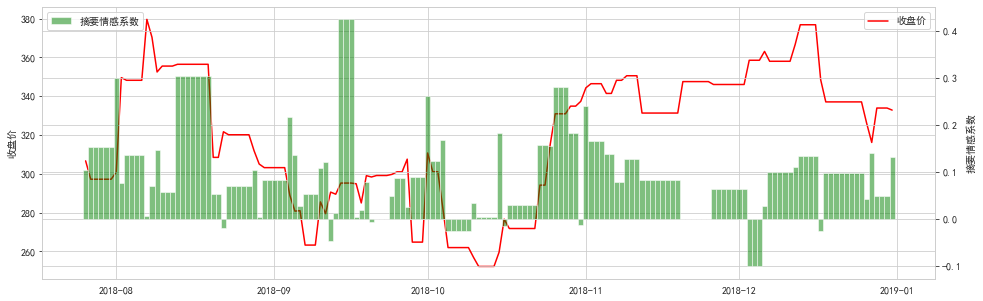

```python
data_PRC = company_df_day2['PRC']
rate = data_PRC.pct_change(periods=10)
emotion_abs=company_df_day2['摘要情感系数']
emotion_forum=company_df_day2['论坛情感系数']
fig=plt.figure(figsize=(16,5))
ax1=fig.add_subplot(111)
ax1.plot(data_PRC,color='red',label='收盘价')
#设置为共用x轴的双y轴图表
ax2=ax1.twinx()
ax2.bar(company_df_day2.index,emotion_abs,color='g',alpha=0.5,label='摘要情感系数',width=1)
# plt.plot(emotion_forum,color='green')
# plt.title('涨跌比')
plt.rcParams['font.sans-serif'] = ['SimHei']
plt.rcParams['axes.unicode_minus'] = False
ax1.set_ylabel('收盘价')
ax2.set_ylabel('摘要情感系数')
#设置图例
ax1.legend(loc=1)
ax2.legend(loc=2)
plt.show()
```

```
             以上为摘要情感系数大小与PRC走势对比关系图，摘要情感值对PRC走势的影响呈略微滞后关系，总体趋势较为准确
```

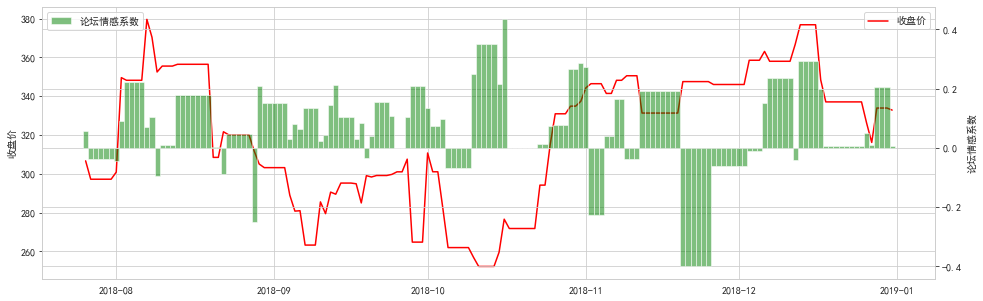

```python
data_PRC = company_df_day['PRC']
rate = data_PRC.pct_change(periods=5)
emotion_abs=company_df_day2['摘要情感系数']
emotion_forum=company_df_day2['论坛情感系数']
fig=plt.figure(figsize=(16,5))
ax1=fig.add_subplot(111)
ax1.plot(data_PRC,color='red',label='收盘价')
#设置为共用x轴的双y轴图表
ax2=ax1.twinx()
ax2.bar(company_df_day2.index,emotion_forum,color='g',alpha=0.5,label='论坛情感系数',width=1)
plt.rcParams['font.sans-serif'] = ['SimHei']
plt.rcParams['axes.unicode_minus'] = False
#设置轴和标签
ax1.set_ylabel('收盘价')
ax2.set_ylabel('论坛情感系数')
#设置图例
ax1.legend(loc=1)
ax2.legend(loc=2)
plt.show()
```

以上为论坛情感系数大小与PRC走势对比关系图，论坛情感值对PRC走势的影响呈略微滞后关系，总体趋势较为准确，特别是中间段，高情感值与上升的关系明显

[figure not shown]

```python
data_PRC = company_df_day['PRC']
# rate = data_PRC.pct_change(periods=10)
emotion_reply=company_df_day2['回帖情感系数']
fig=plt.figure(figsize=(16,5))
ax1=fig.add_subplot(111)
ax1.plot(data_PRC,color='red',label='收盘价')
#设置为共用x轴的双y轴图表
ax2=ax1.twinx()
ax2.bar(company_df_day2.index,emotion_abs,color='g',alpha=0.5,label='回帖情感系数',width=1)
plt.rcParams['font.sans-serif'] = ['SimHei']
plt.rcParams['axes.unicode_minus'] = False
ax1.set_ylabel('收盘价')
ax2.set_ylabel('回帖情感系数')
#设置图例
ax1.legend(loc=1)
ax2.legend(loc=2)
plt.show()
```

```
value_forcast              original   predicted
                  PRC         PRC
2018-12-27  316.13000  333.751084
2018-12-28  333.87000  336.048172
2018-12-29  333.87000  336.740755
2018-12-30  333.87000  336.671070
2018-12-31  332.79999  336.195337
true_value:               OPENPRC      BIDLO        PRC      ASKHI
date
2018-12-27  319.84000  301.50000  316.13000  322.17169
2018-12-28  323.10001  318.41000  333.87000  336.23999
2018-12-29  323.10001  318.41000  333.87000  336.23999
2018-12-30  323.10001  318.41000  333.87000  336.23999
2018-12-31  337.79001  325.26001  332.79999  339.20999
              OPENPRC      BIDLO        PRC      ASKHI     情感总系数
date
2018-07-26  304.85001  303.64111  306.64999  310.70001  0.094187
2018-07-27  307.25000  295.34039  297.17999  307.69330  0.048558
2018-07-28  307.25000  295.34039  297.17999  307.69330  0.048558
2018-07-29  307.25000  295.34039  297.17999  307.69330  0.048558
2018-07-30  307.25000  295.34039  297.17999  307.69330  0.048558
...               ...        ...        ...        ...       ...
2018-12-27  319.84000  301.50000  316.13000  322.17169  0.152237
2018-12-28  323.10001  318.41000  333.87000  336.23999  0.220846
2018-12-29  323.10001  318.41000  333.87000  336.23999  0.220846
2018-12-30  323.10001  318.41000  333.87000  336.23999  0.220846
2018-12-31  337.79001  325.26001  332.79999  339.20999  0.063491

[159 rows x 5 columns]
```

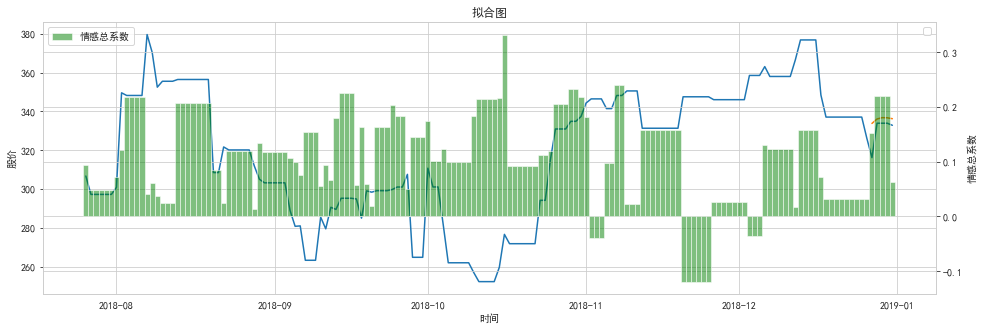

```python
# std = StandardScaler()
# company_df_day1 = std.fit_transform(company_df_day1)  # 标准化训练集和测试集
# x_test = std.fit_transform(x_test)
model = VARMAX(endog=company_df_day1, freq='D',order=(1,1))#建模
varmax_result = model.fit()
predict = varmax_result.forecast(steps=pre_day)
forcast = pd.DataFrame(predict)

value_forcast = pd.concat([pd.DataFrame(company_df_day[['PRC']]), pd.DataFrame(forcast[['PRC']])], axis=1, keys=['original', 'predicted'])
sentiment_forcast = pd.concat([pd.DataFrame(company_df_day[['情感总系数']]), pd.DataFrame(forcast[['情感总系数']])], axis=1, keys=['original', 'predicted'])
print("value_forcast",value_forcast[len(value_forcast)-pre_day:])
print("true_value:", pd.DataFrame(company_df_day[['OPENPRC', 'BIDLO', 'PRC', 'ASKHI']])[-pre_day:])
print(company_df_day)
company_df_day2=company_df_day.iloc[:,len(company_df_day)-pre_day:]

fig=plt.figure(figsize=(16,5))
plt.title('拟合图')
ax1 = fig.add_subplot(111)
ax1.plot(value_forcast)
ax2 = ax1.twinx()
ax1.set_ylabel('股价')
ax2.set_ylabel('情感总系数')
ax2.bar(company_df_day.index,sentiment_forcast[('original','情感总系数')],color='g',alpha=0.5,label='情感总系数',width=1)
ax1.set_xlabel('时间')
#设置图例
ax1.legend(loc=1)
ax2.legend(loc=2)
plt.show()
```

该拟合模型采用的是VARMAX来预测PRC（收盘价）从图中可看出其拟合程度较好，情感总值通过回帖：摘要：论坛=3：3：4的占比来计算，因为观察到论坛 情感系数值更具有显著性，其数据波动较大，具有明显得感情色彩。

模型拟合效果分析

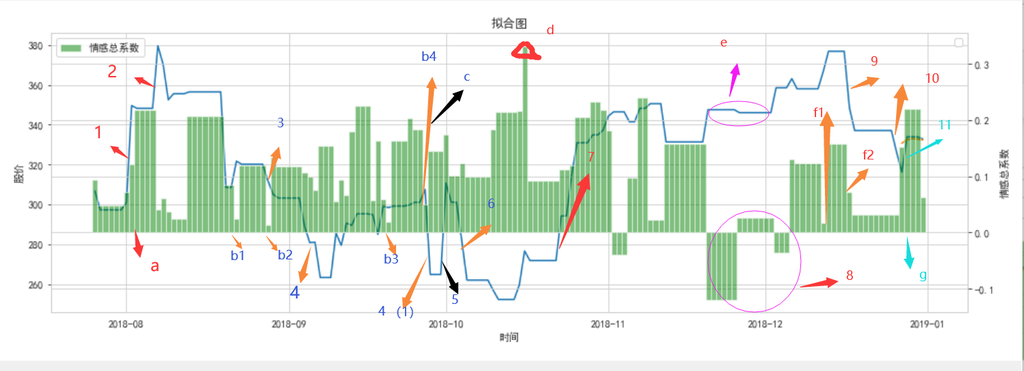

如上图所示，在a区域，情感总系数数值较高，其稍滞后所呈现出的PRC（2）呈明显的上升趋势;当情感总系数出现一个阶梯式的大幅下降（较明显）其随后的PRC出现明显的下降趋势，如b1->3,b2->4,b3->4(1),f1->9,f2->10；当情感总系数出现一个阶梯式的大幅上升（较明显）其随后的PRC出现明显的上升趋势，如c->5,g->11;d为情感总系数的峰值，其滞后影响到7区域段，出现明显的PRC上升趋势，8段情感总值跌为负数，但在其附进范围没有看到PRC明显的下降，猜测可能是由于PRC值的缺失，本实验采用用前一天得收盘价来填充缺失的收盘价，e段呈现出水平线趋势，可能该段为填充值，不具备PRC走势参考价值，故情感总值系数与PRC走势具有明显的关联，其呈现滞后影响的效果较为明显，将情感总值纳入到VARMAX模型的参数之一是合理的，最终的PRC预测值也较为准确。

## 4.3模型正确性检验，利用最后pre_day天当验证集，采取MSE作为评价标准

```python
df_pre=pd.Series(value_forcast[len(value_forcast)-pre_day:][('predicted','PRC')].values,index=value_forcast[len(value_forcast)-pre_day:].index)
df_true=pd.Series(company_df_day[['OPENPRC', 'BIDLO', 'PRC', 'ASKHI']][-pre_day:]['PRC'].values,index=company_df_day[len(company_df_day)-pre_day:].index)
df_MSE=(df_pre-df_true)*(df_pre-df_true)
print(df_pre)
print(df_true)
print("df_MSE",df_MSE.mean())
```

```
2018-12-27    333.751084
2018-12-28    336.048172
2018-12-29    336.740755
2018-12-30    336.671070
2018-12-31    336.195337
Freq: D, dtype: float64
date
2018-12-27    316.13000
2018-12-28    333.87000
2018-12-29    333.87000
2018-12-30    333.87000
2018-12-31    332.79999
Freq: D, dtype: float64
df_MSE 68.57252701182038
```

# 5、总结

通过对本次实验股票价格的分析，加深了我对数据处理与分析的学习，对于模型，在老师得启发下选取了处理多维向量特征得VARMAX模型，把源数据处理好，把有用的数据根据需要的格式处理完，接下来利用对应的模型就可以得到预期的结果。在数据处理方面，遇到比如全标题数据的处理，其中日期错位较为明显，曾经试过手动一个一个找，一个一个解决，等它运行完后报错，根据报错信息提示锁定对应的行，但是操作了十分钟后发现还是没有解决完，故还是采取了用正则表达式提取所有日期列格式不正确的行，观察其结尾都是AM或PM，体会到对于数据处理，不可以试图手动穷举查找，应该用数据得特征进行有效提取与更改；情感分析采用的是textblob，将自然语言的一段话转化成-1到1区间的float数值，再考虑全标题的评论数的数字特征，给每个标题按评论数为参考赋予权重，通过标题与标题的关联，将回帖的情感系数总值赋给每个标题，最终通过公司简写，将对应一家公司对应具体到天的情感系数值利用merge进行合并，注意到其时间为关键的合并枢纽；然后画出股票收盘价（PRC）与各情感系数对应的关系图，发现论坛的情感系数值更具有情感色彩代表意义，故对3各情感系数做了加权平均，利用最终属性向量作为模型参数，并传入模型，预留pre_day作为验证集，利用MSE作为模型的评价标准，在数据集较大的公司尝试TSLA中较为成功。